# tarea_4_28306246

Autor/a

Gustavo Moreno

## Indice de Desarrollo Humano (IDH)

De acuerdo con el Programa de las Naciones Unidas para el Desarrollo(PNUD) el indice de desarrollo humano es una medida resumida del logro promedio en materia de desarrollo que cubre dimensiones de nivel de vida, esperanza de vida y educacion.

## Importacion de datos

Se importo la serie de indice de desarrollo humano para Argentina, Colombia, España y Venezuela con el conjunto de datos disponible en Our World in Data.

## IDH en 2023

Se utilizo el IDH promedio para 2023 de la muestra de paises seleccionados como metrica, con los ultimos datos disponibles, los paises con un IDH alto y bajo.

| entity_name | year | hdi__sex_total | tipo_hdi |
| --- | --- | --- | --- |
| Argentina | 2023 | 0.865 | hdi_alto |
| Colombia | 2023 | 0.788 | hdi_bajo |
| Spain | 2023 | 0.918 | hdi_alto |
| Venezuela | 2023 | 0.709 | hdi_bajo |

## Grafico de barras

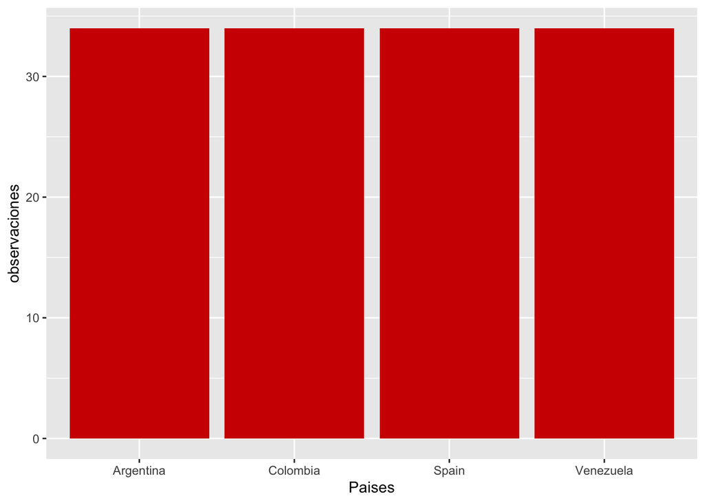

Los paises seleccionados tienen la misma cantidad de observaciones.

## Boxplot

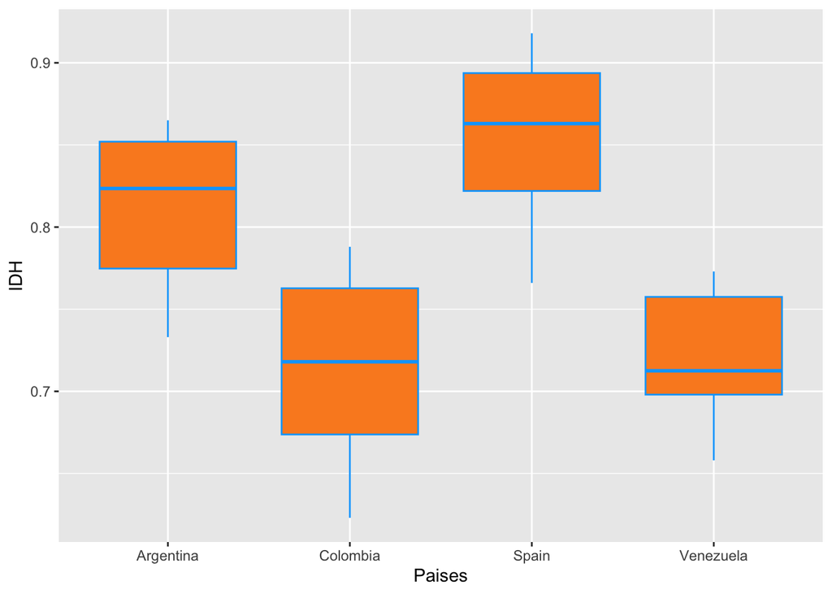

## Histograma

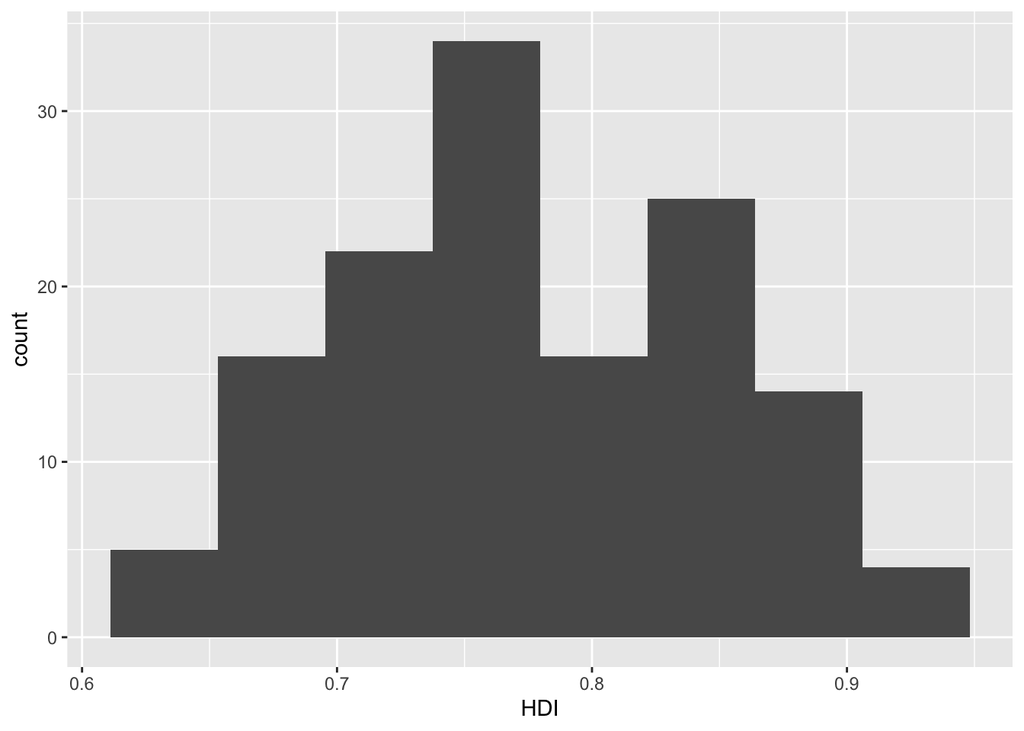

## Histograma por paises

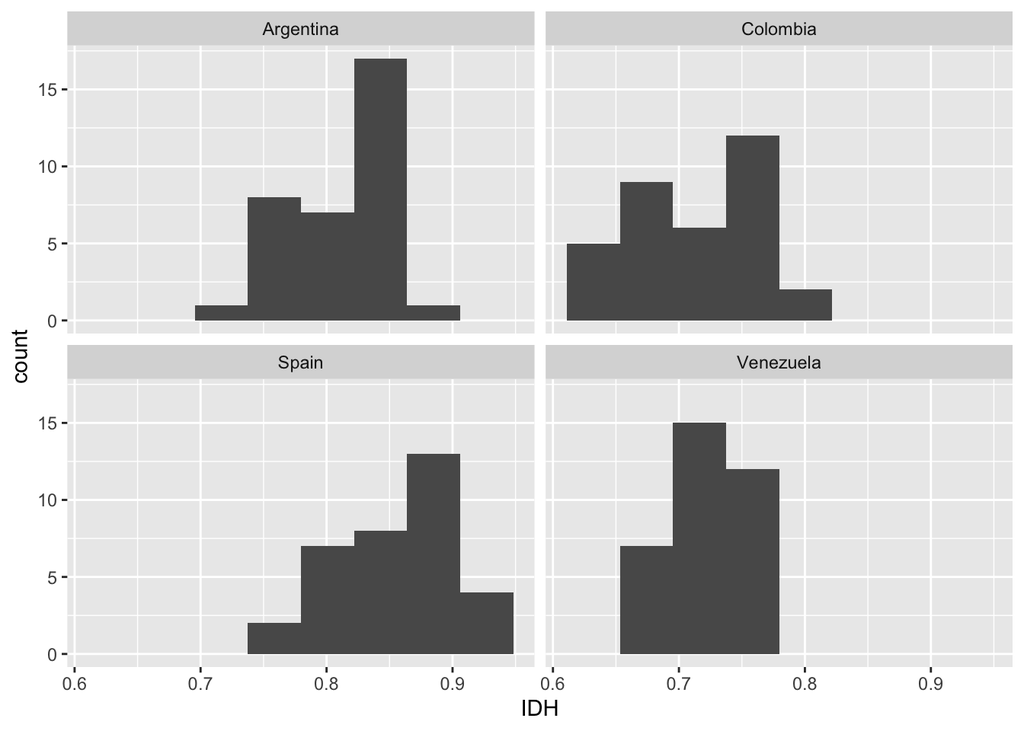

En el caso argentino se destaca que la mayor parte de sus observaciones del IDH estan por encima de 0,8, contrario al caso venezolano y colombiano.

## Grafico de densidad

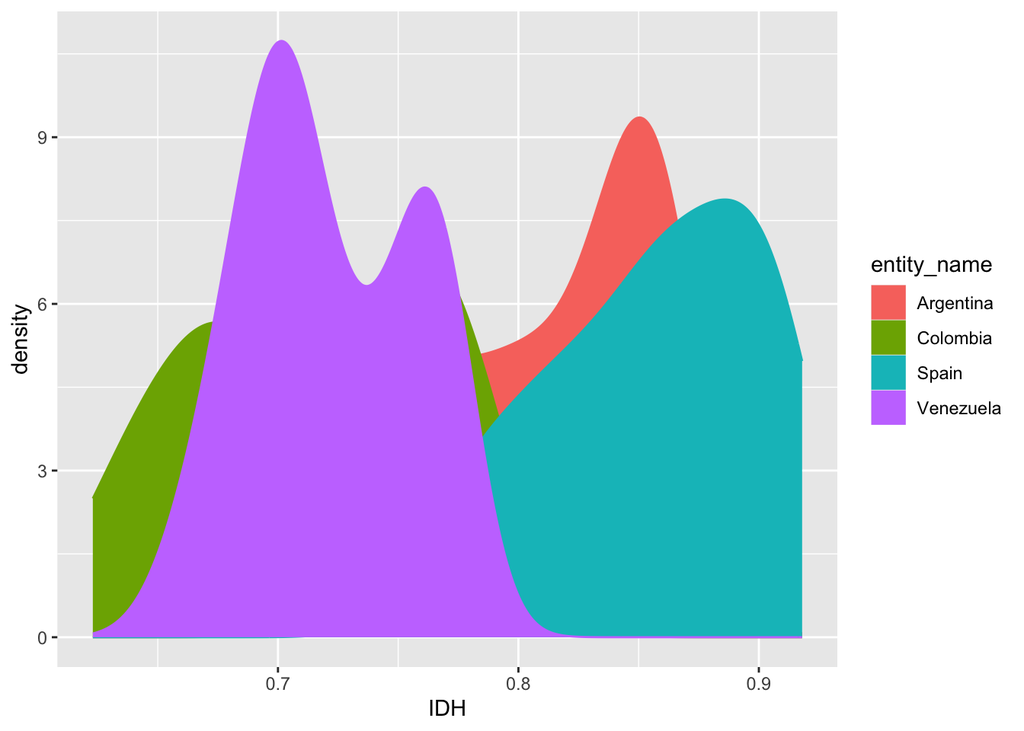

## Grafico de lineas

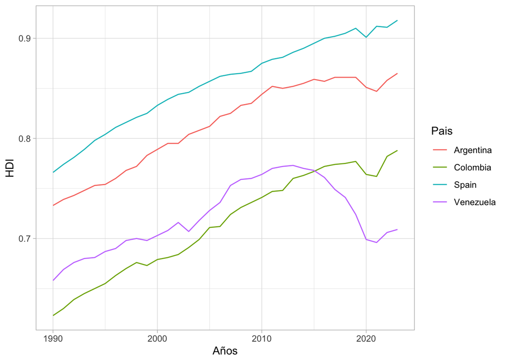

Los paises seleccionados muestran una tendencia positiva a lo largo de la serie con España superando a todos los paises en todo el periodo. Sin embargo, Venezuela ha reducido su IDH desde 2013.

## Tabla GT

Indice de Desarrollo Humano

[output not shown]